# WB2 (4)

```python
!pip install matplotlib==3.4.0
```

```python
import numpy as np
import torchvision
import torchvision.transforms as transforms
import torch
import torch.nn as nn
import torch.nn.functional as F
import matplotlib.pyplot as plt
from collections import namedtuple
from itertools import product
from tqdm import tqdm
from collections import OrderedDict
# import standard PyTorch modules
import torch
import torch.nn as nn
import torch.nn.functional as F
import torch.optim as optim
from torch.utils.tensorboard import SummaryWriter # TensorBoard support

# import torchvision module to handle image manipulation
import torchvision
import torchvision.transforms as transforms

# calculate train time, writing train data to files etc.
import time
import pandas as pd
import json
from IPython.display import clear_output

torch.set_printoptions(linewidth=120)
torch.set_grad_enabled(True);

from sklearn.metrics import confusion_matrix
import seaborn as sn
import pandas as pd
from sklearn.manifold import TSNE
```

## Zbiór danych

```python
# Use standard FashionMNIST dataset
train_set = torchvision.datasets.CIFAR10(
    root = './data/CIFAR10/train',
    train = True,
    download = True,
    transform = transforms.Compose([
        transforms.ToTensor()
    ])
)

# Use standard FashionMNIST dataset
test_set = torchvision.datasets.CIFAR10(
    root = './data/CIFAR10/test',
    train = False,
    download = True,
    transform = transforms.Compose([
        transforms.ToTensor()
    ])
)

classes = ('plane', 'car', 'bird', 'cat', 'deer', 'dog', 'frog', 'horse', 'ship', 'truck')
mask = [i for i in range(round(len(train_set.data)/10))]
train_set_mini = torch.utils.data.Subset(train_set, mask)
test_set_mini =  torch.utils.data.Subset(test_set, mask)
```

```
Files already downloaded and verified
Files already downloaded and verified
```

```python
def reshape_data(dataset, miniSize=0.4):
    reshaped = {}
    for (i, d) in tqdm(enumerate(dataset), total=len(dataset)):
        if d[1] not in reshaped:
            reshaped[d[1]] = []
        reshaped[d[1]].append(i)

    return reshaped
train_set_reshaped = reshape_data(train_set)
test_set_reshaped = reshape_data(test_set)
```

```
Rozmiar zbioru treningowego: 5000
Rozmiar zbioru testowego: 5000
Liczba klas: 10
Rozmiar obrazka: 3x32x32 - 3x32x32
```

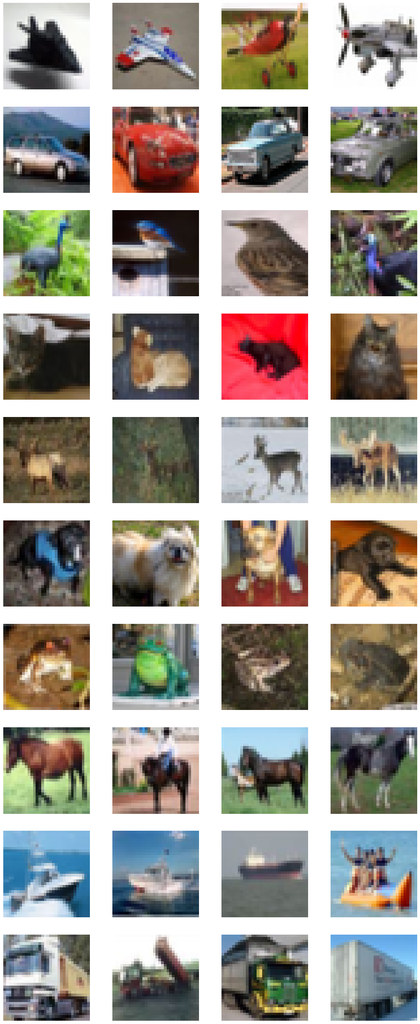

```
Rozkład klas:
```

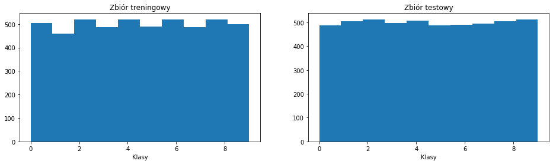

```python
minWidth = float('inf')
minHeight = float('inf')
maxWidth = 0
maxHeight = 0
for i in train_set_mini:
    minWidth = min(minWidth, i[0].size()[2])
    minHeight = min(minHeight, i[0].size()[1])
    maxWidth = max(maxWidth, i[0].size()[2])
    maxHeight = max(maxHeight, i[0].size()[1])

print("Rozmiar zbioru treningowego:", len(train_set_mini))
print("Rozmiar zbioru testowego:", len(test_set_mini))
print("Liczba klas:", len(train_set_reshaped))
print("Rozmiar obrazka:", "3x"+str(minHeight)+"x"+str(minWidth)+" - 3x"+str(maxHeight)+"x"+str(maxWidth))

fig, axes = plt.subplots(len(train_set_reshaped), 4, figsize=(16, 4*len(train_set_reshaped)), squeeze=False)
for i in train_set_reshaped:
    for j in range(4):
        ax = axes[i, j]
        ax.axis('off')
        ax.imshow(train_set[train_set_reshaped[i][j]][0].permute(1, 2, 0)  )
plt.show()

print("Rozkład klas:")
fig, (ax1, ax2) = plt.subplots(1, 2, figsize=(16, 4))
ax1.hist([i[1] for i in train_set_mini], bins=len(train_set_reshaped))
ax1.set_title('Zbiór treningowy')
ax1.set_xlabel('Klasy');

ax2.hist([i[1] for i in test_set_mini], bins=len(train_set_reshaped))
ax2.set_title('Zbiór testowy')
ax2.set_xlabel('Klasy')
plt.show()
```

Zbiór ten jest bardzo do treningu - wszystkie obrazy są identycznych rozmiarów, klas jest jedynie dziesięć, i zarówno zbiór treningowy jak i testowy zawiera podobną ilość obrazów każdej klasy.

## Struktura sieci

Źródło: https://github.com/kuangliu/pytorch-cifar

```python
class BasicBlock(nn.Module):
    expansion = 1

    def __init__(self, in_planes, planes, stride=1):
        super(BasicBlock, self).__init__()
        self.conv1 = nn.Conv2d(
            in_planes, planes, kernel_size=3, stride=stride, padding=1, bias=False)
        self.bn1 = nn.BatchNorm2d(planes)
        self.conv2 = nn.Conv2d(planes, planes, kernel_size=3,
                               stride=1, padding=1, bias=False)
        self.bn2 = nn.BatchNorm2d(planes)

        self.shortcut = nn.Sequential()
        if stride != 1 or in_planes != self.expansion*planes:
            self.shortcut = nn.Sequential(
                nn.Conv2d(in_planes, self.expansion*planes,
                          kernel_size=1, stride=stride, bias=False),
                nn.BatchNorm2d(self.expansion*planes)
            )

    def forward(self, x):
        out = F.relu(self.bn1(self.conv1(x)))
        out = self.bn2(self.conv2(out))
        out += self.shortcut(x)
        out = F.relu(out)
        return out


class Bottleneck(nn.Module):
    expansion = 4

    def __init__(self, in_planes, planes, stride=1):
        super(Bottleneck, self).__init__()
        self.conv1 = nn.Conv2d(in_planes, planes, kernel_size=1, bias=False)
        self.bn1 = nn.BatchNorm2d(planes)
        self.conv2 = nn.Conv2d(planes, planes, kernel_size=3,
                               stride=stride, padding=1, bias=False)
        self.bn2 = nn.BatchNorm2d(planes)
        self.conv3 = nn.Conv2d(planes, self.expansion *
                               planes, kernel_size=1, bias=False)
        self.bn3 = nn.BatchNorm2d(self.expansion*planes)

        self.shortcut = nn.Sequential()
        if stride != 1 or in_planes != self.expansion*planes:
            self.shortcut = nn.Sequential(
                nn.Conv2d(in_planes, self.expansion*planes,
                          kernel_size=1, stride=stride, bias=False),
                nn.BatchNorm2d(self.expansion*planes)
            )

    def forward(self, x):
        out = F.relu(self.bn1(self.conv1(x)))
        out = F.relu(self.bn2(self.conv2(out)))
        out = self.bn3(self.conv3(out))
        out += self.shortcut(x)
        out = F.relu(out)
        return out


class ResNet(nn.Module):
    def __init__(self, block, num_blocks, num_classes=10):
        super(ResNet, self).__init__()
        self.in_planes = 64

        self.conv1 = nn.Conv2d(3, 64, kernel_size=3,
                               stride=1, padding=1, bias=False)
        self.bn1 = nn.BatchNorm2d(64)
        self.layer1 = self._make_layer(block, 64, num_blocks[0], stride=1)
        self.layer2 = self._make_layer(block, 128, num_blocks[1], stride=2)
        self.layer3 = self._make_layer(block, 256, num_blocks[2], stride=2)
        self.layer4 = self._make_layer(block, 512, num_blocks[3], stride=2)
        self.linear = nn.Linear(512*block.expansion, num_classes)

    def _make_layer(self, block, planes, num_blocks, stride):
        strides = [stride] + [1]*(num_blocks-1)
        layers = []
        for stride in strides:
            layers.append(block(self.in_planes, planes, stride))
            self.in_planes = planes * block.expansion
        return nn.Sequential(*layers)

    def forward(self, x):
        out = F.relu(self.bn1(self.conv1(x)))
        out = self.layer1(out)
        out = self.layer2(out)
        out = self.layer3(out)
        out = self.layer4(out)
        out = F.avg_pool2d(out, 4)
        out = out.view(out.size(0), -1)
        out = self.linear(out)
        return out

    def partial_forward(self, x):
        out = F.relu(self.bn1(self.conv1(x)))
        out = self.layer1(out)
        out = self.layer2(out)
        out = self.layer3(out)
        out = self.layer4(out)
        out = F.avg_pool2d(out, 4)
        out = out.view(out.size(0), -1)
        return out

class ResNetDropout(nn.Module):
    def __init__(self, block, num_blocks, num_classes=10):
        super(ResNetDropout, self).__init__()
        self.in_planes = 64

        self.conv1 = nn.Conv2d(3, 64, kernel_size=3,
                               stride=1, padding=1, bias=False)
        self.bn1 = nn.BatchNorm2d(64)
        self.layer1 = self._make_layer(block, 64, num_blocks[0], stride=1)
        self.layer2 = self._make_layer(block, 128, num_blocks[1], stride=2)
        self.layer3 = self._make_layer(block, 256, num_blocks[2], stride=2)
        self.layer4 = self._make_layer(block, 512, num_blocks[3], stride=2)
        self.linear = nn.Linear(512*block.expansion, num_classes)
        self.dropout = nn.Dropout(0.25)

    def _make_layer(self, block, planes, num_blocks, stride):
        strides = [stride] + [1]*(num_blocks-1)
        layers = []
        for stride in strides:
            layers.append(block(self.in_planes, planes, stride))
            self.in_planes = planes * block.expansion
        return nn.Sequential(*layers)

    def forward(self, x):
        out = F.relu(self.bn1(self.conv1(x)))
        out = self.dropout(out)
        out = self.layer1(out)
        out = self.dropout(out)
        out = self.layer2(out)
        out = self.dropout(out)
        out = self.layer3(out)
        out = self.dropout(out)
        out = self.layer4(out)
        out = self.dropout(out)
        out = F.avg_pool2d(out, 4)
        out = out.view(out.size(0), -1)
        out = self.linear(out)
        return out

    def partial_forward(self, x):
        out = F.relu(self.bn1(self.conv1(x)))
        out = self.dropout(out)
        out = self.layer1(out)
        out = self.dropout(out)
        out = self.layer2(out)
        out = self.dropout(out)
        out = self.layer3(out)
        out = self.dropout(out)
        out = self.layer4(out)
        out = self.dropout(out)
        out = F.avg_pool2d(out, 4)
        out = out.view(out.size(0), -1)
        out = self.linear(out)
        return out

def ResNet18():
    return ResNet(BasicBlock, [2, 2, 2, 2])

def ResNetDropout18():
    return ResNetDropout(BasicBlock, [2, 2, 2, 2])

def ResNet34():
    return ResNet(BasicBlock, [3, 4, 6, 3])


def ResNet50():
    return ResNet(Bottleneck, [3, 4, 6, 3])


def ResNet101():
    return ResNet(Bottleneck, [3, 4, 23, 3])


def ResNet152():
    return ResNet(Bottleneck, [3, 8, 36, 3])
```

## Trenowanie sieci

Źródło: https://towardsdatascience.com/build-a-fashion-mnist-cnn-pytorch-style-efb297e22582

```python
if torch.cuda.is_available():
  DEVICE = "cuda:0"
else:
  DEVICE = "cpu"

params = OrderedDict(
    lr = [.001],
    batch_size = [10],
    shuffle = [True]
)
epochs = 15

# Read in the hyper-parameters and return a Run namedtuple containing all the
# combinations of hyper-parameters
class RunBuilder():
  @staticmethod
  def get_runs(params):

    Run = namedtuple('Run', params.keys())

    runs = []
    for v in product(*params.values()):
      runs.append(Run(*v))

    return runs

# Helper class, help track loss, accuracy, epoch time, run time,
# hyper-parameters etc. Also record to TensorBoard and write into csv, json
class RunManager():
  def __init__(self):

    # tracking every epoch count, loss, accuracy, time
    self.epoch_count = 0
    self.epoch_loss = 0
    self.epoch_num_correct = 0
    self.epoch_start_time = None

    # tracking every run count, run data, hyper-params used, time
    self.run_params = None
    self.run_count = 0
    self.run_data = []
    self.run_start_time = None

    # record model, loader and TensorBoard
    self.network = None
    self.loader = None
    self.tb = None

  # record the count, hyper-param, model, loader of each run
  # record sample images and network graph to TensorBoard
  def begin_run(self, run, network, loader):

    self.run_start_time = time.time()

    self.run_params = run
    self.run_count += 1

    self.network = network
    self.loader = loader
    self.tb = SummaryWriter(comment=f'-{run}')

    images, labels = next(iter(self.loader))
    grid = torchvision.utils.make_grid(images.to(DEVICE))

    self.tb.add_image('images', grid)
    self.tb.add_graph(self.network, images.to(DEVICE))

  # when run ends, close TensorBoard, zero epoch count
  def end_run(self):
    self.tb.close()
    self.epoch_count = 0

  # zero epoch count, loss, accuracy,
  def begin_epoch(self):
    self.epoch_start_time = time.time()

    self.epoch_count += 1
    self.epoch_loss = 0
    self.epoch_num_correct = 0
    self.epoch_num_correct_test = 0

  #
  def end_epoch(self):
    # calculate epoch duration and run duration(accumulate)
    epoch_duration = time.time() - self.epoch_start_time
    run_duration = time.time() - self.run_start_time

    # record epoch loss and accuracy
    loss = self.epoch_loss / len(self.loader.dataset)
    accuracy = self.epoch_num_correct / len(self.loader.dataset)
    accuracy_test = self.epoch_num_correct_test / len(self.loader.dataset)

    # Record epoch loss and accuracy to TensorBoard
    self.tb.add_scalar('Loss', loss, self.epoch_count)
    self.tb.add_scalar('Accuracy', accuracy, self.epoch_count)
    self.tb.add_scalar('Accuracy (test)', accuracy_test, self.epoch_count)

    # Record params to TensorBoard
    for name, param in self.network.named_parameters():
      self.tb.add_histogram(name, param, self.epoch_count)
      self.tb.add_histogram(f'{name}.grad', param.grad, self.epoch_count)

    # Write into 'results' (OrderedDict) for all run related data
    results = OrderedDict()
    results["run"] = self.run_count
    results["epoch"] = self.epoch_count
    results["loss"] = loss
    results["accuracy"] = accuracy
    results["accuracy test"] = accuracy_test
    results["epoch duration"] = epoch_duration
    results["run duration"] = run_duration

    # Record hyper-params into 'results'
    for k,v in self.run_params._asdict().items(): results[k] = v
    self.run_data.append(results)
    df = pd.DataFrame.from_dict(self.run_data, orient = 'columns')

    # display epoch information and show progress
    clear_output(wait=True)
    display(df)

  # accumulate loss of batch into entire epoch loss
  def track_loss(self, loss):
    # multiply batch size so variety of batch sizes can be compared
    self.epoch_loss += loss.item() * self.loader.batch_size

  # accumulate number of corrects of batch into entire epoch num_correct
  def track_num_correct(self, preds, labels):
    self.epoch_num_correct += self._get_num_correct(preds, labels)
  def track_num_correct_test(self, preds, labels):
    self.epoch_num_correct_test += self._get_num_correct(preds, labels)

  @torch.no_grad()
  def _get_num_correct(self, preds, labels):
    return preds.argmax(dim=1).eq(labels).sum().item()

  # save end results of all runs into csv, json for further analysis
  def save(self, fileName):

    pd.DataFrame.from_dict(
        self.run_data,
        orient = 'columns',
    ).to_csv(f'{fileName}.csv')

    with open(f'{fileName}.json', 'w', encoding='utf-8') as f:
      json.dump(self.run_data, f, ensure_ascii=False, indent=4)

def trainNetwork(networkBuilder, dataset, dataset_test):
  m = RunManager()

  # get all runs from params using RunBuilder class
  for run in RunBuilder.get_runs(params):

      # if params changes, following line of code should reflect the changes too
      network = networkBuilder().to(DEVICE)
      loader = torch.utils.data.DataLoader(dataset, batch_size = run.batch_size,num_workers=2)
      loader_test = torch.utils.data.DataLoader(dataset_test, batch_size = run.batch_size,num_workers=2)
      optimizer = optim.Adam(network.parameters(), lr=run.lr)

      m.begin_run(run, network, loader)
      for epoch in range(epochs):

        m.begin_epoch()
        for batch in loader:

          images = batch[0].to(DEVICE)
          labels = batch[1].to(DEVICE)
          preds = network(images)
          loss = F.cross_entropy(preds, labels)

          optimizer.zero_grad()
          loss.backward()
          optimizer.step()

          m.track_loss(loss)
          m.track_num_correct(preds, labels)

        for batch in loader_test:
          images = batch[0].to(DEVICE)
          labels = batch[1].to(DEVICE)
          preds = network(images)
          m.track_num_correct_test(preds, labels)

        m.end_epoch()
      m.end_run()

  # when all runs are done, save results to files
  m.save('results')
  return m
```

```python
man_18 = trainNetwork(ResNet18, train_set_mini, test_set_mini)
```

|  | run | epoch | loss | accuracy | accuracy test | epoch duration | run duration | lr | batch_size | shuffle |
| --- | --- | --- | --- | --- | --- | --- | --- | --- | --- | --- |
| 0 | 1 | 1 | 2.037114 | 0.2562 | 0.3180 | 52.588385 | 53.301417 | 0.001 | 10 | True |
| 1 | 1 | 2 | 1.754835 | 0.3546 | 0.3562 | 43.478957 | 99.393737 | 0.001 | 10 | True |
| 2 | 1 | 3 | 1.607612 | 0.3984 | 0.3956 | 41.994260 | 144.020875 | 0.001 | 10 | True |
| 3 | 1 | 4 | 1.469054 | 0.4520 | 0.4264 | 42.090101 | 188.776221 | 0.001 | 10 | True |
| 4 | 1 | 5 | 1.320001 | 0.5220 | 0.4530 | 41.853760 | 233.208721 | 0.001 | 10 | True |
| 5 | 1 | 6 | 1.140567 | 0.5930 | 0.4716 | 41.966533 | 277.818027 | 0.001 | 10 | True |
| 6 | 1 | 7 | 0.926087 | 0.6742 | 0.4738 | 41.929235 | 322.359280 | 0.001 | 10 | True |
| 7 | 1 | 8 | 0.694763 | 0.7516 | 0.4280 | 42.094400 | 367.059083 | 0.001 | 10 | True |
| 8 | 1 | 9 | 0.523317 | 0.8186 | 0.4640 | 42.021996 | 411.768772 | 0.001 | 10 | True |
| 9 | 1 | 10 | 0.365395 | 0.8716 | 0.4782 | 41.860521 | 456.246138 | 0.001 | 10 | True |
| 10 | 1 | 11 | 0.241885 | 0.9174 | 0.5188 | 42.220288 | 501.060803 | 0.001 | 10 | True |
| 11 | 1 | 12 | 0.195116 | 0.9330 | 0.5230 | 42.069746 | 545.678676 | 0.001 | 10 | True |
| 12 | 1 | 13 | 0.162495 | 0.9452 | 0.5250 | 42.156920 | 590.540647 | 0.001 | 10 | True |
| 13 | 1 | 14 | 0.118036 | 0.9586 | 0.5434 | 42.103973 | 635.305620 | 0.001 | 10 | True |
| 14 | 1 | 15 | 0.101606 | 0.9666 | 0.5274 | 42.217581 | 680.110504 | 0.001 | 10 | True |

```python
man_34 = trainNetwork(ResNet34, train_set_mini, test_set_mini)
```

|  | run | epoch | loss | accuracy | accuracy test | epoch duration | run duration | lr | batch_size | shuffle |
| --- | --- | --- | --- | --- | --- | --- | --- | --- | --- | --- |
| 0 | 1 | 1 | 2.192099 | 0.2018 | 0.2618 | 76.308670 | 77.433696 | 0.001 | 10 | True |
| 1 | 1 | 2 | 1.926914 | 0.2864 | 0.3026 | 76.072560 | 158.559330 | 0.001 | 10 | True |
| 2 | 1 | 3 | 1.793070 | 0.3394 | 0.3334 | 76.449185 | 239.929983 | 0.001 | 10 | True |
| 3 | 1 | 4 | 1.698437 | 0.3730 | 0.3602 | 76.625492 | 321.760712 | 0.001 | 10 | True |
| 4 | 1 | 5 | 1.599996 | 0.4056 | 0.3870 | 76.497782 | 403.433654 | 0.001 | 10 | True |
| 5 | 1 | 6 | 1.498823 | 0.4492 | 0.4260 | 76.825287 | 485.416098 | 0.001 | 10 | True |
| 6 | 1 | 7 | 1.378064 | 0.4980 | 0.4354 | 76.949347 | 567.534132 | 0.001 | 10 | True |
| 7 | 1 | 8 | 1.257010 | 0.5428 | 0.4502 | 76.765959 | 649.597343 | 0.001 | 10 | True |
| 8 | 1 | 9 | 1.119082 | 0.6006 | 0.4660 | 76.888977 | 731.600452 | 0.001 | 10 | True |
| 9 | 1 | 10 | 0.945990 | 0.6564 | 0.4480 | 76.784420 | 813.540591 | 0.001 | 10 | True |
| 10 | 1 | 11 | 0.781546 | 0.7208 | 0.4622 | 76.756572 | 895.472209 | 0.001 | 10 | True |
| 11 | 1 | 12 | 0.616522 | 0.7754 | 0.4668 | 76.822997 | 977.426353 | 0.001 | 10 | True |
| 12 | 1 | 13 | 0.490214 | 0.8286 | 0.4526 | 76.646883 | 1059.119120 | 0.001 | 10 | True |
| 13 | 1 | 14 | 0.374533 | 0.8678 | 0.4654 | 76.698848 | 1140.905776 | 0.001 | 10 | True |
| 14 | 1 | 15 | 0.274206 | 0.9036 | 0.4908 | 76.870885 | 1222.912032 | 0.001 | 10 | True |

```python
man_drop_18 = trainNetwork(ResNetDropout18, train_set_mini, test_set_mini)
```

|  | run | epoch | loss | accuracy | accuracy test | epoch duration | run duration | lr | batch_size | shuffle |
| --- | --- | --- | --- | --- | --- | --- | --- | --- | --- | --- |
| 0 | 1 | 1 | 2.020710 | 0.2692 | 0.3354 | 42.576763 | 43.305461 | 0.001 | 10 | True |
| 1 | 1 | 2 | 1.743600 | 0.3574 | 0.3616 | 42.625286 | 88.536640 | 0.001 | 10 | True |
| 2 | 1 | 3 | 1.597345 | 0.4086 | 0.3916 | 42.717826 | 133.991507 | 0.001 | 10 | True |
| 3 | 1 | 4 | 1.477530 | 0.4634 | 0.4274 | 42.729902 | 179.414466 | 0.001 | 10 | True |
| 4 | 1 | 5 | 1.357647 | 0.5104 | 0.4502 | 42.612284 | 224.742854 | 0.001 | 10 | True |
| 5 | 1 | 6 | 1.226122 | 0.5616 | 0.4702 | 42.772116 | 270.210229 | 0.001 | 10 | True |
| 6 | 1 | 7 | 1.081205 | 0.6060 | 0.4642 | 42.743405 | 315.645218 | 0.001 | 10 | True |
| 7 | 1 | 8 | 0.934808 | 0.6664 | 0.4876 | 42.661982 | 361.028888 | 0.001 | 10 | True |
| 8 | 1 | 9 | 0.767605 | 0.7298 | 0.5036 | 42.605352 | 406.260207 | 0.001 | 10 | True |
| 9 | 1 | 10 | 0.610638 | 0.7828 | 0.4938 | 42.584197 | 451.527531 | 0.001 | 10 | True |
| 10 | 1 | 11 | 0.472890 | 0.8370 | 0.5172 | 42.619461 | 496.812403 | 0.001 | 10 | True |
| 11 | 1 | 12 | 0.361143 | 0.8750 | 0.5078 | 42.600898 | 542.111254 | 0.001 | 10 | True |
| 12 | 1 | 13 | 0.281425 | 0.9072 | 0.5276 | 42.507803 | 587.278066 | 0.001 | 10 | True |
| 13 | 1 | 14 | 0.242441 | 0.9192 | 0.5264 | 42.610639 | 632.616556 | 0.001 | 10 | True |
| 14 | 1 | 15 | 0.184511 | 0.9330 | 0.5488 | 42.592796 | 677.890222 | 0.001 | 10 | True |

## Porównanie ResNet18 i ResNet34

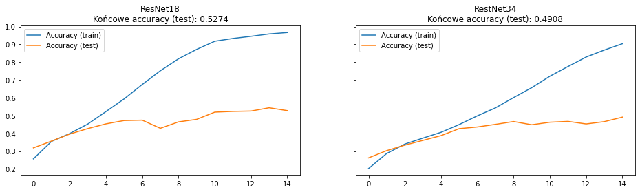

```python
def plotAccuracy(man, ax, title):
  ax.set_title(title+'\nKońcowe accuracy (test): '+str(man.run_data[-1]['accuracy test']))
  ax.plot(range(len(man.run_data)), [i['accuracy'] for i in man.run_data])
  ax.plot(range(len(man.run_data)), [i['accuracy test'] for i in man.run_data])
  ax.legend(['Accuracy (train)', 'Accuracy (test)'])

fig, (ax1, ax2) = plt.subplots(1, 2, figsize=(16, 4), sharey=True)
plotAccuracy(man_18, ax1, 'ResNet18')
plotAccuracy(man_34, ax2, 'RestNet34')

plt.show()
```

Jak widzimy, mimo że sieć była wytrenowana jedynie na 10% danych, uzyskała około 50% accuracy. Nie jest to wynik wystarczająco dobry żeby wykorzystywać sieć na predykcje, jednak przy dłuższym treningu i wykorzystaniu całego zbioru danych, sieć wyuczyłaby się do wystarczająco dobrego accuracy.

W porównaniu architektury ResNet18 i ResNet34 widać nieoczekiwaną zależność - mniejsza architektura uzyskuje lepsze wyniki. Jest tak ponieważ trening trwał zaledwie 15 epok. Analizując wylresy accuracy, widzimy że ResNet18 na początku uczył się bardzo szybko, a później jego prędkość zmalała. W przypadku ResNet34 nie ma takiej zależności - sieć uczy się co prawda wolniej, ale nie widać punktu przegięcia. Można zatem wnioskować, że przy znacząco dłuższym treningu większa sieć uzsykała by lepsze wyniki.

## Wykorzystanie dropout (ResNet18)

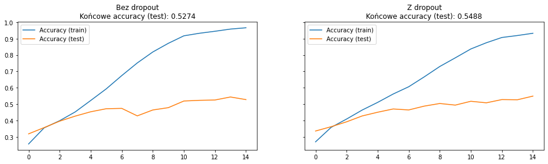

```python
def plotAccuracy(man, ax, title):
  ax.set_title(title+'\nKońcowe accuracy (test): '+str(man.run_data[-1]['accuracy test']))
  ax.plot(range(len(man.run_data)), [i['accuracy'] for i in man.run_data])
  ax.plot(range(len(man.run_data)), [i['accuracy test'] for i in man.run_data])
  ax.legend(['Accuracy (train)', 'Accuracy (test)'])

fig, (ax1, ax2) = plt.subplots(1, 2, figsize=(16, 4), sharey=True)
plotAccuracy(man_18, ax1, 'Bez dropout')
plotAccuracy(man_drop_18, ax2, 'Z dropout')

plt.show()
```

Jak można się było tego spodziewać, wykorzystanie dropoutu poprawiło accuracy na zbiorze testowym. Widzimy także dosyć ciekawą zależność na samym wykresie, gdzie sieć bez dropoutu ma chwilowe i znaczące spadki accuracy, a sieć z dropout zachowuje się dużo bardziej stabilnie.

## Macierz konfuzji

Źródło: https://christianbernecker.medium.com/how-to-create-a-confusion-matrix-in-pytorch-38d06a7f04b7

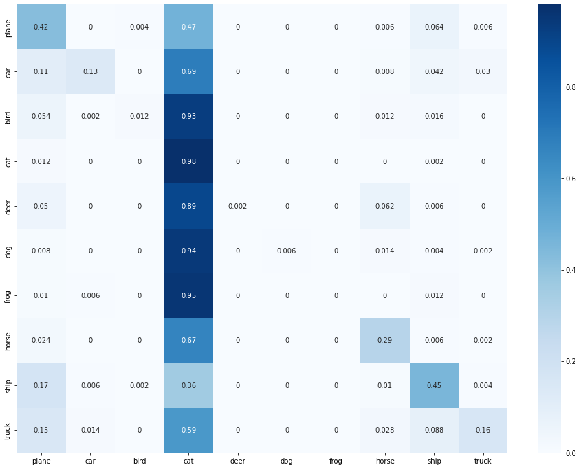

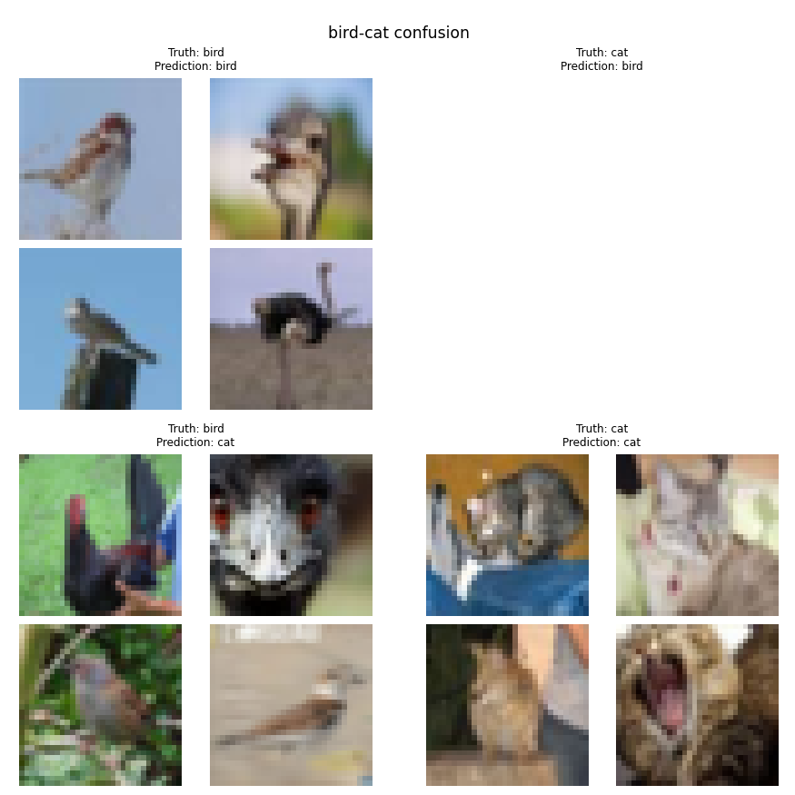

```python
def confusionMatrix(man, dataset, classes, explain):
  y_pred = []
  y_true = []
  explanation = [[], [], [], []]

  # iterate over test data
  for inputs, labels in torch.utils.data.DataLoader(dataset):
          output = man.network(inputs.to(DEVICE)) # Feed Network

          output = (torch.max(torch.exp(output), 1)[1]).data.cpu().numpy()
          y_pred.extend(output) # Save Prediction

          labels = labels.data.cpu().numpy()
          y_true.extend(labels) # Save Truth

          for i in range(len(labels)):
            if labels[i] == explain[0]:
              if output[i] == explain[0]:
                explanation[0].append(inputs[i])
              elif output[i] == explain[1]:
                explanation[2].append(inputs[i])
            elif labels[i] == explain[1]:
              if output[i] == explain[0]:
                explanation[1].append(inputs[i])
              elif output[i] == explain[1]:
                explanation[3].append(inputs[i])

  # Build confusion matrix
  cf_matrix = confusion_matrix(y_true, y_pred)
  df_cm = pd.DataFrame(cf_matrix/np.sum(cf_matrix) *10, index = [i for i in classes],
                      columns = [i for i in classes])
  fig = plt.figure(figsize = (16, 12))
  sn.heatmap(df_cm, annot=True, cmap="Blues")
  plt.show()


  def sh(i, j):
    return "Truth: "+classes[explain[i]]+"\nPrediction: "+classes[explain[j]]
  fig = plt.figure(constrained_layout=True, figsize=(12, 12))
  fig.suptitle('\n'+classes[explain[0]]+'-'+classes[explain[1]]+" confusion", fontsize='xx-large')
  subfigs = fig.subfigures(2, 2, wspace=0.07)
  subtitles = [sh(0,0),sh(1,0),sh(0,1),sh(1,1)]

  for outerind, subfig in enumerate(subfigs.flat):
      subfig.suptitle(subtitles[outerind])
      axs = subfig.subplots(2, 2)
      for i in range(len(axs.flat)):
          axs.flat[i].axis('off')
      for i in range(min(len(axs.flat), len(explanation[outerind]))):
          axs.flat[i].imshow(explanation[outerind][i].permute(1, 2, 0)  )

  plt.show()
confusionMatrix(man_drop_18, test_set_mini, classes, (2, 3))
```

Pomimo uzyskania nienajgorszego wyniku, utworzenie macierzy konfuzji pokazuje nam znaczący problem w nauczonej przez nas sieci - bardzo dużą skłonność to klasyfikowania wszystkiego jako koty. Oczywistym wnioskiem zatem jest że sieć nie powinna być dalej wykorzystywana, a problem dużego biasu wobec klasyfikacji jako koty dogłębniej zgłębiony.

## Wizualizacja T-SNE

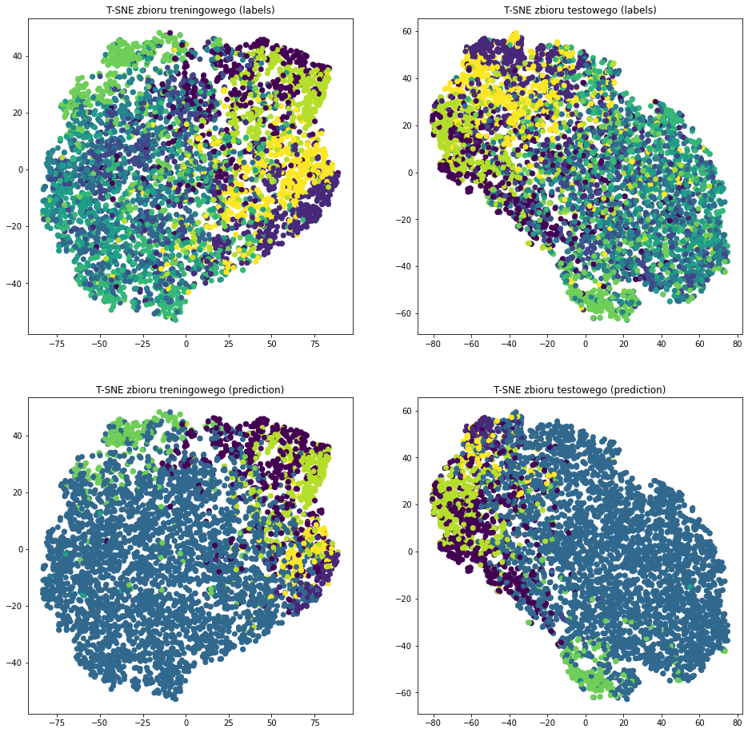

```python
def tsneVisualize(man, dataset, ax1, ax2, title):
  poz = []
  cls = []
  pred = []

  for inputs, labels in torch.utils.data.DataLoader(dataset):
    output = man.network.partial_forward(inputs.to(DEVICE))
    predict = man.network(inputs.to(DEVICE))
    poz.append(output[0].cpu().detach().numpy())
    pred.append((torch.max(torch.exp(predict), 1)[1]).data.cpu().numpy())
    cls.append(labels[0].numpy())

  tsne = TSNE().fit_transform(poz)
  ax1.scatter(tsne[:,0], tsne[:,1], c=cls)
  ax1.set_title(title+" (labels)")
  ax2.scatter(tsne[:,0], tsne[:,1], c=pred)
  ax2.set_title(title+" (prediction)")

fig, ((ax1, ax2), (ax3, ax4)) = plt.subplots(2, 2, figsize=(16, 16))
tsneVisualize(man_drop_18, train_set_mini, ax1, ax3, "T-SNE zbioru treningowego")
tsneVisualize(man_drop_18, test_set_mini, ax2, ax4, "T-SNE zbioru testowego")
```

Wykorzystanie T-SNE także bardzo dokładnie reprezentuje nam problem który tu się pojawił. Brak widocznego podziału na klastry świadczy o kiepskim rozróżnieniu klas przez sieć. Można także zauważyć że punkty układające się w widoczne struktury są dobrze klasyfikowane przez sieć, ale te które się tak nie układają są zgrubnie klasyfikowane jako kot. Jest to spodziewane zachowanie, bo to właśnie na podstawie tej reprezentacji wektorowej podejmowana jest decyzja o klasie.